# Practical Machine Learning Course Project

jvmunoz: José Vicente Muñoz

Sunday, December 21, 2014

## Background

Using devices such as Jawbone Up, Nike FuelBand, and Fitbit it is now possible to collect a large amount of data about personal activity relatively inexpensively. These type of devices are part of the quantified self movement ??? a group of enthusiasts who take measurements about themselves regularly to improve their health, to find patterns in their behavior, or because they are tech geeks. One thing that people regularly do is quantify how much of a particular activity they do, but they rarely quantify how well they do it. In this project, your goal will be to use data from accelerometers on the belt, forearm, arm, and dumbell of 6 participants. They were asked to perform barbell lifts correctly and incorrectly in 5 different ways. More information is available from the website here: http://groupware.les.inf.puc-rio.br/har (see the section on the Weight Lifting Exercise Dataset).

## Data

The training data for this project are available here:

https://d396qusza40orc.cloudfront.net/predmachlearn/pml-training.csv

The test data are available here:

https://d396qusza40orc.cloudfront.net/predmachlearn/pml-testing.csv

The data for this project comes from this original source: http://groupware.les.inf.puc-rio.br/har. If you use the document you create for this class for any purpose please cite them as they have been very generous in allowing their data to be used for this kind of assignment.

## What we should submit

The goal of the project is to predict the manner in which they did the exercise. This is the “classe” variable in the training set. You may use any of the other variables to predict with. You should create a report describing how you built your model, how you used cross validation, what you think the expected out of sample error is, and why you made the choices you did. You will also use your prediction model to predict 20 different test cases.

1. Your submission should consist of a link to a Github repo with your R markdown and compiled HTML file describing your analysis. Please constrain the text of the writeup to < 2000 words and the number of figures to be less than 5. It will make it easier for the graders if you submit a repo with a gh-pages branch so the HTML page can be viewed online (and you always want to make it easy on graders :-).
2. You should also apply your machine learning algorithm to the 20 test cases available in the test data above. Please submit your predictions in appropriate format to the programming assignment for automated grading. See the programming assignment for additional details.

## Environment settings

Libraries and Seed

```r
library(knitr)
opts_chunk$set(echo = TRUE, results = 'hold')

library(caret)
library(rattle)
library(randomForest)
set.seed(727)
```

## Getting the data

We remove ID variable so that it does not interfer with ML Algorithms

```r
training <- read.csv(url("http://d396qusza40orc.cloudfront.net/predmachlearn/pml-training.csv"), header=TRUE, as.is = TRUE, stringsAsFactors = FALSE, sep=',', na.strings=c("NA","#DIV/0!",""))
training <- training[,-1]
training$classe <- as.factor(training$classe)
testing <- read.csv(url("http://d396qusza40orc.cloudfront.net/predmachlearn/pml-testing.csv"), header=TRUE, as.is = TRUE, stringsAsFactors = FALSE, sep=',', na.strings=c("NA","#DIV/0!",""))
testing <- testing[,-1]
```

## Arranging the data

There are a lot of values NA or useless or empty variables for the prediction. We will consider as predictors only those variables that do not have all values equal to NA in the test dataset

```r
NAindex <- apply(testing,2,function(x) {sum(is.na(x))})
training <- training[,which(NAindex == 0)]
testing <- testing[,which(NAindex == 0)]
dim(training); dim(testing)
```

```
## [1] 19622    59
## [1] 20 59
```

Remove near zero variance variables

```r
nzv <- nearZeroVar(training,saveMetrics=TRUE)
training <- training[,nzv$nzv==FALSE]
nzv <- nearZeroVar(testing,saveMetrics=TRUE)
testing <- testing[,nzv$nzv==FALSE]
dim(training); dim(testing)
```

```
## [1] 19622    58
## [1] 20 58
```

## Partioning the training set into two

Split the dataset into a 70% training and 30% validating dataset.

```r
inTrain <- createDataPartition(training$classe, p=0.7, list=FALSE)
myTraining <- training[inTrain, ]
myTesting <- training[-inTrain, ]
```

## Using ML algorithms for prediction: Random Forest

Train model with Random Forest due to it yields a high accuracy rate. We will use Parallelism.

```r
library(parallel)
library(doParallel)
cl <- makeCluster(detectCores() - 1)
registerDoParallel(cl)
```

We set control parameters and proceed with the training of the model

```r
fitControl <- trainControl(method="repeatedcv",
                           number=5,
                           repeats=1,
                           allowParallel=TRUE,
                           verboseIter=FALSE)

modFit <- train(classe ~., method="rf", data=myTraining, trControl=fitControl)

stopCluster(cl)

modFit
```

```
## Random Forest
##
## 13737 samples
##    57 predictor
##     5 classes: 'A', 'B', 'C', 'D', 'E'
##
## No pre-processing
## Resampling: Cross-Validated (5 fold, repeated 1 times)
##
## Summary of sample sizes: 10990, 10991, 10988, 10990, 10989
##
## Resampling results across tuning parameters:
##
##   mtry  Accuracy   Kappa      Accuracy SD   Kappa SD
##    2    0.9873328  0.9839738  0.0032829668  0.0041552221
##   40    0.9986168  0.9982504  0.0008300835  0.0010500269
##   79    0.9984713  0.9980664  0.0004744589  0.0006002511
##
## Accuracy was used to select the optimal model using  the largest value.
## The final value used for the model was mtry = 40.
```

## Model Evaluation

Model Evaluation on the training dataset and the testing dataset

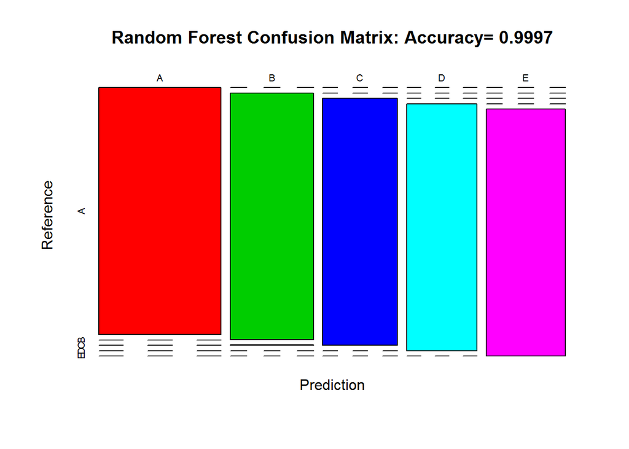

```
## Confusion Matrix and Statistics
##
##           Reference
## Prediction    A    B    C    D    E
##          A 3906    0    0    0    0
##          B    0 2658    0    0    0
##          C    0    0 2396    0    0
##          D    0    0    0 2252    0
##          E    0    0    0    0 2525
##
## Overall Statistics
##
##                Accuracy : 1
##                  95% CI : (0.9997, 1)
##     No Information Rate : 0.2843
##     P-Value [Acc > NIR] : < 2.2e-16
##
##                   Kappa : 1
##  Mcnemar's Test P-Value : NA
##
## Statistics by Class:
##
##                      Class: A Class: B Class: C Class: D Class: E
## Sensitivity            1.0000   1.0000   1.0000   1.0000   1.0000
## Specificity            1.0000   1.0000   1.0000   1.0000   1.0000
## Pos Pred Value         1.0000   1.0000   1.0000   1.0000   1.0000
## Neg Pred Value         1.0000   1.0000   1.0000   1.0000   1.0000
## Prevalence             0.2843   0.1935   0.1744   0.1639   0.1838
## Detection Rate         0.2843   0.1935   0.1744   0.1639   0.1838
## Detection Prevalence   0.2843   0.1935   0.1744   0.1639   0.1838
## Balanced Accuracy      1.0000   1.0000   1.0000   1.0000   1.0000
## Confusion Matrix and Statistics
##
##           Reference
## Prediction    A    B    C    D    E
##          A 1674    0    0    0    0
##          B    0 1139    2    0    0
##          C    0    0 1024    0    0
##          D    0    0    0  964    0
##          E    0    0    0    0 1082
##
## Overall Statistics
##
##                Accuracy : 0.9997
##                  95% CI : (0.9988, 1)
##     No Information Rate : 0.2845
##     P-Value [Acc > NIR] : < 2.2e-16
##
##                   Kappa : 0.9996
##  Mcnemar's Test P-Value : NA
##
## Statistics by Class:
##
##                      Class: A Class: B Class: C Class: D Class: E
## Sensitivity            1.0000   1.0000   0.9981   1.0000   1.0000
## Specificity            1.0000   0.9996   1.0000   1.0000   1.0000
## Pos Pred Value         1.0000   0.9982   1.0000   1.0000   1.0000
## Neg Pred Value         1.0000   1.0000   0.9996   1.0000   1.0000
## Prevalence             0.2845   0.1935   0.1743   0.1638   0.1839
## Detection Rate         0.2845   0.1935   0.1740   0.1638   0.1839
## Detection Prevalence   0.2845   0.1939   0.1740   0.1638   0.1839
## Balanced Accuracy      1.0000   0.9998   0.9990   1.0000   1.0000
```

```r
trainingPred <- predict(modFit, myTraining)
confusionMatrix(trainingPred, myTraining$classe)

testingPred <- predict(modFit, myTesting)
cmrf <- confusionMatrix(testingPred, myTesting$classe)
cmrf

classes <- unique(training$classe)
class_colors <- 1 + as.integer(classes)
plot(cmrf$table, col = class_colors, main = paste("Random Forest Confusion Matrix: Accuracy=", round(cmrf$overall['Accuracy'], 4)))
```

Random Forests yields very good results. Model Accuracy as tested over Validation set = 99.97%.

```r
varImp(modFit)
modFit$finalModel
```

```
## rf variable importance
##
##   only 20 most important variables shown (out of 79)
##
##                                Overall
## raw_timestamp_part_1           100.000
## num_window                      43.750
## roll_belt                       43.443
## pitch_forearm                   27.585
## magnet_dumbbell_z               18.619
## magnet_dumbbell_y               16.826
## roll_forearm                    13.988
## yaw_belt                        13.144
## pitch_belt                      12.675
## cvtd_timestamp30/11/2011 17:12  11.423
## cvtd_timestamp02/12/2011 14:58   9.243
## cvtd_timestamp28/11/2011 14:15   8.564
## cvtd_timestamp02/12/2011 13:33   7.605
## magnet_dumbbell_x                6.703
## accel_belt_z                     6.330
## accel_dumbbell_y                 6.081
## roll_dumbbell                    5.822
## magnet_belt_y                    5.391
## accel_forearm_x                  5.155
## cvtd_timestamp05/12/2011 11:24   5.143
##
## Call:
##  randomForest(x = x, y = y, mtry = param$mtry)
##                Type of random forest: classification
##                      Number of trees: 500
## No. of variables tried at each split: 40
##
##         OOB estimate of  error rate: 0.09%
## Confusion matrix:
##      A    B    C    D    E  class.error
## A 3906    0    0    0    0 0.0000000000
## B    1 2655    2    0    0 0.0011286682
## C    0    2 2394    0    0 0.0008347245
## D    0    0    5 2246    1 0.0026642984
## E    0    0    0    2 2523 0.0007920792
```

The estimated error rate is less than 0.1%

## Predictions on the test data

```r
answers <- predict(modFit,testing)
answers
```

```
##  [1] B A B A A E D B A A B C B A E E A B B B
## Levels: A B C D E
```

## Submistion to Coursera

```r
pml_write_files = function(x){
  n = length(x)
  for(i in 1:n){
    filename = paste0("problem_id_",i,".txt")
    write.table(x[i],file=filename,quote=FALSE,row.names=FALSE,col.names=FALSE)
  }
}
pml_write_files(answers)
```